# 社會科學統計方法

蔡佳泓

3/19/2021

# 1 課程目標

本週上課將介紹`R`的控制流程，也就是條件判斷與迴圈，讓電腦可以按照給定的邏輯，反覆執行指令，一直到滿足條件為止，這對於運算以及擷取資料非常有幫助。例如我們隨機找到10位民眾，想依據民眾的年齡是否在18歲以上，判斷是否應該訪問他們，並且顯示成為一個資料框，可寫語法運算如下：

```r
age<-c(34, 12, 19, 21, 22, 30, 16, 18, 17, 39)
 f<-function(x){
  interview<-ifelse(x>=18, "Yes", "No")
  return(data.frame(Age=x, Interview=interview, row.names=NULL))
 }

f(age)
```

```
##    Age Interview
## 1   34       Yes
## 2   12        No
## 3   19       Yes
## 4   21       Yes
## 5   22       Yes
## 6   30       Yes
## 7   16        No
## 8   18       Yes
## 9   17        No
## 10  39       Yes
```

# 2 條件判斷

## 2.1 ifelse()函式

`ifelse()`適用在「非A即B」的邏輯，也就是若A為真則進行某一動作，若A不為真則不進行。  
例如面訪員到某一個家戶訪問，裡面有四人，訪員需要戶中抽樣，但是前提是只訪問18歲以上成年人，語法可以這樣寫：

```r
x=c(20, 50, 16, 18)
interview<-ifelse(x>=18, "Yes", "No")
print(interview)
```

```
## [1] "Yes" "Yes" "No"  "Yes"
```

`ifelse()`可以判斷一個向量的真偽，其功能類似先前提到的變數轉換：

```r
vote <- rep(NA, 3)
vote[x>=18]<-"Yes"
vote[x<18]<-"No"
vote
```

```
## [1] "Yes" "Yes" "No"  "Yes"
```

`ifelse()`也可以轉換字串為字串或者是數字，也可以把日期轉換為字串或是數字。

```r
S<-c("2018-01-01", "2019-02-01", "2021-01-01", "2021-03-01")
S <- as.Date(S, format='%Y-%m-%d')
day<-as.Date("2020/12/28", format='%Y/%m/%d')
new.S<-ifelse(difftime(day, S)>=0, "Earlier", "Later")
new.S
```

```
## [1] "Earlier" "Earlier" "Later"   "Later"
```

當條件成立時的執行的動作可以是函數，例如在日光節約時間結束之後，下午茶時間延後一個小時。假設日光節約時間在11月5日結束，三個日期的下午茶時間可計算如下：

```r
ds<-as.POSIXct("2018-11-05 00:00:00",
      format = "%Y-%m-%d %H:%M:%S", tz="Asia/Taipei")

teatime<-as.POSIXct(c("2018-07-01 13:50:00", "2018-12-01 14:10:00",
      "2019-02-02 14:15:00"),  format = "%Y-%m-%d %H:%M:%S", tz="Asia/Taipei")

hrs <- function(u) {
 x <- u * 3600
 return(x)
}

ifelse(difftime(teatime, ds)>=0, paste(teatime+hrs(1)), paste(teatime))
```

[1] “2018-07-01 13:50:00” “2018-12-01 15:10:00” “2019-02-02 15:15:00”

請注意時間的格式，以及設定時區的函數`as.POSIXct()`。另外，`paste()`函數可貼上計算結果。

## 2.2 if-else() 函式

`if-else` 可以幫助我們建立一個條件式的函數，當函數內的向量滿足某個條件，便會進行某一個動作。要注意一次只能處理一個向量的元素。

```r
temperature<-c(31)
if (temperature>28){
   cat ("Turn on air condition")
}else {
  cat ("Turn off air condition")
}
```

```
## Turn on air condition
```

也可以進行運算

```r
speed<-50
if (speed>=70){
     print(speed)
}else {
    print(speed*1.6)
}
```

```
## [1] 80
```

```r
mpg <- mtcars$mpg
y <- rep(0, length(mpg))
if (any(mpg>=50)){
      mtcars[which(mpg>=50),]
} else{
      print('NA')
}
```

[1] “NA”

此處使用`any()`這個函式，表示當物件或是多個物件滿足某一條件則回傳TRUE。例如：

```r
A<-c(-1, 1.5); B<-c(2); C<-c('OK')
any (A>0)
```

```
## [1] TRUE
```

```r
any (is.numeric(A) & is.numeric(B) & is.numeric(C))
```

```
## [1] FALSE
```

```r
any (is.numeric(A) | is.numeric(B) | is.numeric(C))
```

```
## [1] TRUE
```

## 2.3 if-else if-else

`if-else if-else` 可以幫助我們建立一個條件式的函數，當函數內的向量滿足第一個條件，便會進行第一個動作，滿足第二個條件，便會進行第二個動作，一直到結束。例如電影的長度如果長過180分鐘則是太長，165分鐘是長，不到165分鐘是短。 同樣的，一次只能處理一個向量的元素。

```r
movie<-c(176)
if(movie>=180){
     cat('Very long')
    }else if(movie>=165){
    cat('Long')
  }else{
          cat('Short')
}
```

```
## Long
```

在寫if-else時，請注意`}`應該與`else`或是`else if`連在一起。  
假設在入住前3個月（90天）訂飯店為原價的85折，2個月（60天）訂飯店為原價的9折，入住前1周到兩個月是原價，入住日期為1周內則是原價加上兩成。如果入住日期為今年7月20日，原價是3600元，請練習今天的日期以及隔兩週後的今天訂房的話，分別需要多少錢？

```r
booking<-as.Date(Sys.Date(), format='%Y-%m-%d')
booking
```

```
## [1] "2021-02-12"
```

```r
checkin<-as.Date(c("2021-07-20"),    format='%Y-%m-%d')
X<-3600
if (difftime(checkin, booking)>90){
    print (X*0.85)
}else if (difftime(checkin, booking)>=60){
   print (X*0.9)
}else if (difftime(checkin, booking)>=7){
   print (X)
}else{
  print (X*1.2)
}
```

```
## [1] 3060
```

```r
 booking <-booking + 14
if (difftime(checkin, booking)>90){
    print (X*0.85)
}else if (difftime(checkin, booking)>=60){
   print (X*0.9)
}else if (difftime(checkin, booking)>=30){
   print (X)
}else{
  print (X*1.2)
}
```

```
## [1] 3060
```

# 3 迴圈

## 3.1 for迴圈

`for`迴圈的功能是系統根據起始的條件，反覆進行同一動作。  
例如重複顯示一個句子$n$次：

```r
for (U in 1:5){
  cat("All work and no play","\n")
}
```

```
## All work and no play
## All work and no play
## All work and no play
## All work and no play
## All work and no play
```

在這個迴圈中，U是一個變數，雖然U沒有出現在後面的語法，但是系統會執行該語法所設定的次數。 也可以貼上次數：

```r
for (i in 1:5){
  cat("All work and no play", paste(i), "times \n")
}
```

```
## All work and no play 1 times
## All work and no play 2 times
## All work and no play 3 times
## All work and no play 4 times
## All work and no play 5 times
```

在這個迴圈中，我們用`paste()`這個函數貼上$i$這個變數的值。

又例如從1加到10：

```r
sum<-0
for (i in 1:10){
  sum = sum + i
  }
print(sum)
```

```
## [1] 55
```

如果我們想保留每一次的計算結果，可以用迴圈，儲存計算結果在一個新變數：

```r
sum<-0
x<-c(0:10)
y<-c()
for (i in 1:10){
  sum = sum + x[i]
  y[i]=sum
  cat(y[i], '+', x[i+1], '=', paste(sum(y[i]+x[i+1])),"\n")
    }
```

```
## 0 + 1 = 1
## 1 + 2 = 3
## 3 + 3 = 6
## 6 + 4 = 10
## 10 + 5 = 15
## 15 + 6 = 21
## 21 + 7 = 28
## 28 + 8 = 36
## 36 + 9 = 45
## 45 + 10 = 55
```

```r
y
```

```
##  [1]  0  1  3  6 10 15 21 28 36 45
```

### 3.1.1 用sample隨機產生亂數

擲三顆公正的六面骰子1000次並且加總點數，將每一次得到的總和畫成長條圖 3.1：

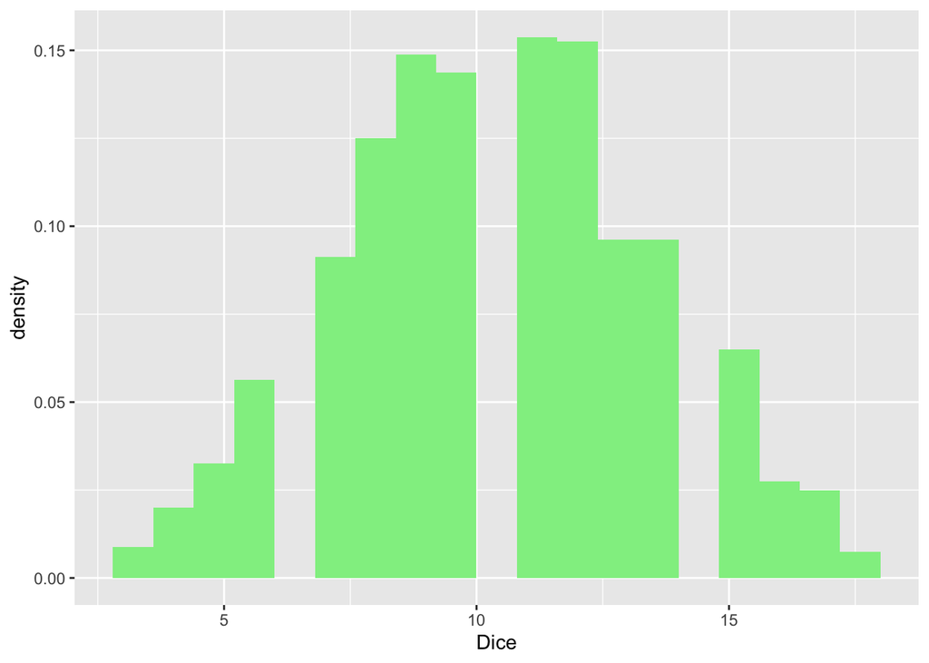

Figure 3.1: 三顆骰子點數長條圖

```r
set.seed(02138)
dice <- seq(1:6)
x <- c()
for (i in 1:1000){
  x[i]<-sum(sample(dice, 1), sample(dice, 1), sample(dice, 1))
}
# graphic
df<-data.frame(Dice=x)
library(ggplot2)
g <- ggplot(aes(Dice), data=df) +
  geom_histogram(binwidth = 0.8,
    fill='lightgreen', aes(y=..density..),
    position="identity")
g
```

可以看出點數的總和近似常態分佈，集中在10點附近。

這個迴圈運用到「索引」的概念，紀錄每一次抽樣並且加總的結果，但是不需要顯示在螢幕上，而是成為一個向量，作為後續統計的資料。

### 3.1.2 for 與函數

撲克牌點數為1到13點，如果我們規定抽出三張牌，前兩張的點數總和小於17，而且其中一張牌小於10，那麼就抽第三張，然後顯示三張的總和；如果不符合前一個條件，那麼就顯示兩張的總和。當我們給定隨機亂數的數字，我們設定的條件式函數根據隨機亂數得到的結果輸出。

```r
set.seed(02138)
card<-function(x) {
set.seed(x)
for (i in 1:3)
  x[i]<-sample(1:13, 1)
  if (x[1]+x[2]<17 & x[1]<10 | x[2]<10 ){
  print(x[1:3])
  cat(sum(x[1:3]),"is sum of three cards \n")
    }else {
        print(x[1:2])
        cat(sum(x[1:2]), "is sum of the first 2 cards \n")
        }
  }
card(100); card(5003); card(02138)
```

```
## [1] 10  7  6
## 23 is sum of three cards
```

```
## [1] 3 2 6
## 11 is sum of three cards
```

```
## [1] 11  5  1
## 17 is sum of three cards
```

上述的程式可以產生一個自訂函數`card()`，該函數的參數x是任意整數，將產生隨機亂數。這個迴圈同樣運用到「索引」的概念。

### 3.1.3 for 與 if-else if-else

```r
today<-as.Date(Sys.Date(), format='%Y-%m-%d')

hotel <- function(checkin){
n <- length(checkin)
price <- 3000
diff <- difftime(checkin, today)

for (i in 1:n)
    if (diff[i]>90){
          print(checkin[i])
             cat (round(diff[i]/30,1), "months:", price*0.85, "\n")
      }else if (diff[i]>=60){
              print(checkin[i])
              cat (round(diff[i]/30,1), "months:",price*0.9,"\n")
    }else if (diff[i]>=30){
            print(checkin[i])
            cat (round(diff[i]/30,1), "months:",price,"\n")
    }else{
            print(checkin[i])
            cat (diff[i],  "days:",price*1.2, "\n")
    }
 }
checkin<-as.Date(c("2020-12-31", "2020-04-20","2020-05-20",
                   "2020-06-01"), format='%Y-%m-%d')
hotel(checkin)
```

```
## [1] "2020-12-31"
## -43 days: 3600
## [1] "2020-04-20"
## -298 days: 3600
## [1] "2020-05-20"
## -268 days: 3600
## [1] "2020-06-01"
## -256 days: 3600
```

### 3.1.4 雙重迴圈

如果需要兩個變數才能產生所需要的結果，可以考慮迴圈之中的迴圈，例如我們想知道11到20的乘法表，需要兩個變數相乘：

```r
multiplication <- matrix(nrow=10, ncol=10)
for (i in 1:dim(multiplication)[1]){
  for (j in 1:dim(multiplication)[2]){
    multiplication[i,j] <- (i+10)*(j+10)
  }
}
rownames(multiplication)<-c(11:20)
colnames(multiplication)<-c(11:20)
multiplication
```

```
##     11  12  13  14  15  16  17  18  19  20
## 11 121 132 143 154 165 176 187 198 209 220
## 12 132 144 156 168 180 192 204 216 228 240
## 13 143 156 169 182 195 208 221 234 247 260
## 14 154 168 182 196 210 224 238 252 266 280
## 15 165 180 195 210 225 240 255 270 285 300
## 16 176 192 208 224 240 256 272 288 304 320
## 17 187 204 221 238 255 272 289 306 323 340
## 18 198 216 234 252 270 288 306 324 342 360
## 19 209 228 247 266 285 304 323 342 361 380
## 20 220 240 260 280 300 320 340 360 380 400
```

☛請嘗試用陣列加上迴圈產生三維的資料，例如我們模擬兩種隨機抽樣方式，第一種方式從5種隨機分佈每次抽出1, 10, 100, 200, 500, 1000個樣本，然後計算其平均值。第二種方式除了從5種隨機分佈每次抽出1, 10, 100, 200, 500, 1000個樣本，然後計算其平均值，還要重複以上步驟10, 100,1000次，分別計算平均值。

```markdown
set.seed(02138)
sampleresult <- matrix(nrow=6, ncol=5)
R<-c(1, 10, 100, 200, 500, 1000)
L<-list(rnorm(1e+04,0,1), rnorm(1e+05,0,1),
rnorm(1e+06,0,1), rnorm(1e+07,0,1), rnorm(1e+08,0,1))

for (i in 1:length(R)){
  for (j in 1:5){
    sampleresult[i,j] <- mean(sample (L[[j]], size=R[i], replace=T))
  }
}
sampleresult

#replication
sampleresult2 <- array(dim=c(6, 5, 3))
S<-c(10,100, 1000)
for (i in 1:length(R)){
  for (j in 1:5){
    for(s in 1:length(S)){
      su<-c();
    sampleresult2[i,j,s] <- mean({su[s]=mean(sample
    (L[[j]], size=R[i], replace=T))})
  }
  }
}
sampleresult2
```

### 3.1.5 清理資料

`for`迴圈可以幫助我們清理資料，例如讀取一筆23個縣市的統計資料：

```r
cs3171d1a<-here::here("data","CS3171D1A.csv")
stat.dat<-read.csv(cs3171d1a,
                  header=TRUE,sep=";",dec=".",
                  fileEncoding="BIG5")
head(stat.dat)
```

```
##                        X 臺北縣 宜蘭縣 桃園縣 新竹縣 苗栗縣 臺中縣 彰化縣
## 1 老年人口比率(65歲以上)     NA     NA     NA     NA     NA     NA     NA
## 2                   2000   6.37  10.20   7.46   9.69  10.98   7.16   9.42
## 3                   2001   6.44  10.49   7.49   9.91  11.21   7.32   9.73
## 4                   2002   6.55  10.82   7.51  10.17  11.57   7.50  10.03
## 5                   2003   6.67  11.17   7.56  10.39  11.87   7.68  10.31
## 6                   2004   6.86  11.54   7.62  10.58  12.19   7.90  10.65
##   南投縣 雲林縣 嘉義縣 臺南縣 高雄縣 屏東縣 臺東縣 花蓮縣 澎湖縣 基隆市 新竹市
## 1     NA     NA     NA     NA     NA     NA     NA     NA     NA     NA     NA
## 2  10.60  11.61  12.41  10.75   8.35  10.00  11.27  10.73  14.40   8.81   8.46
## 3  10.90  11.99  12.75  11.04   8.52  10.25  11.40  10.83  14.29   9.06   8.50
## 4  11.23  12.41  13.14  11.31   8.75  10.54  11.55  11.00  14.42   9.28   8.59
## 5  11.56  12.82  13.58  11.56   8.95  10.84  11.76  11.19  14.58   9.47   8.69
## 6  11.96  13.26  13.98  11.82   9.16  11.13  12.01  11.41  14.78   9.71   8.81
##   臺中市 嘉義市 臺南市 臺北市 高雄市
## 1     NA     NA     NA     NA     NA
## 2   6.49   8.67   7.69   9.67   7.16
## 3   6.60   8.85   7.85   9.94   7.41
## 4   6.79   9.15   8.06  10.25   7.63
## 5   6.94   9.46   8.24  10.58   7.93
## 6   7.15   9.70   8.46  10.92   8.24
```

這筆資料的最左邊一欄有一個變數名稱，但是不是位在第一列，而是在第二列，我們如何正確地讀取每一列的資料？

- 首先創造一個有23個元素的向量
- 對某一個變數進行23次的迴圈
- 第一個元素應該來自於資料的第二列、第二行

```r
old.2000<-rep(NA, 23)  #讀取2010年老年人口比率
 for (u in 1:23){
   old.2000[u]<-stat.dat[2,u+1]
 }
old.2000
```

```
##  [1]  6.37 10.20  7.46  9.69 10.98  7.16  9.42 10.60 11.61 12.41 10.75  8.35
## [13] 10.00 11.27 10.73 14.40  8.81  8.46  6.49  8.67  7.69  9.67  7.16
```

## 3.2 while

如果要系統在執行到滿足某一個條件時中斷，可以用`while`迴圈。例如：

```r
power<-0
while (power <= 12) {
  if (2^power<1000){
    cat(2^power, "\n")
    }else{
        cat("Stop")
    }
  power <- power +1
}
```

```
## 1
## 2
## 4
## 8
## 16
## 32
## 64
## 128
## 256
## 512
## StopStopStop
```

如果用`for`迴圈，可以輸出$2^{0}$到$2^{12}$，但是無法像`while`中斷迴圈：

```r
 for (a in -1:11){
    a <- a +1
   print(2^a)
 }
```

```
## [1] 1
## [1] 2
## [1] 4
## [1] 8
## [1] 16
## [1] 32
## [1] 64
## [1] 128
## [1] 256
## [1] 512
## [1] 1024
## [1] 2048
## [1] 4096
```

## 3.3 break

`break`可以在滿足某項條件情況下中斷迴圈，以上面的迴圈為例，假設我們要在超過1000時中斷：

```r
power<-0
while (power <= 12) {
  if (2^power<1000){
    cat(2^power, "\n")
    }else{
        cat("Stop")
        break
    }
  power <- power +1
}
```

```
## 1
## 2
## 4
## 8
## 16
## 32
## 64
## 128
## 256
## 512
## Stop
```

也可以應用在訂旅館的例子中，例如超過原價就停止計算房價：

```r
today<-as.Date(Sys.Date(), format='%Y-%m-%d')

hotel <- function(checkin){
n <- length(checkin)
price <- 3000
diff <- difftime(checkin, today)
for (i in 1:n)
    if (diff[i]>90){
          print(checkin[i])
             cat (round(diff[i]/30,1), "months:", price*0.85, "\n")
      }else if (diff[i]>=60){
              print(checkin[i])
              cat (round(diff[i]/30,1), "months:",price*0.9,"\n")
    }else if (diff[i]>=30){
            print(checkin[i])
            cat (round(diff[i]/30,1), "months:",price,"\n")

    }else{
            print(checkin[i])
            cat("Over the budget")
            break
            #cat (diff[i],  "days:",price*1.2, "\n")
    }
 }
checkin<-as.Date(c("2018-12-31", "2018-04-20","2018-05-20",
                   "2018-06-01","2018-06-30"), format='%Y-%m-%d')
checkin<-c(checkin, today+7)
hotel(checkin)
```

```
## [1] "2018-12-31"
## Over the budget
```

## 3.4 next

如果想跳過滿足某個條件的迴圈，執行下一個迴圈，可用`next`。例如：

```r
for (i in 1:10){
     if (i<= 4){
       next
     }
    #a <- a +1
    cat(i, "squared is ", i^2, "\n")
 }
```

```
## 5 squared is  25
## 6 squared is  36
## 7 squared is  49
## 8 squared is  64
## 9 squared is  81
## 10 squared is  100
```

# 4 遞迴

[output not shown]

[output not shown]

[output not shown]

$$0,1,1,2,3,5,8,13,21$$

我們可以用遞迴的函數得到Fibonacci數列：

```r
recurse_fibonacci <- function(n) {
if(n <= 1) {
  return(n)
} else {
  return(recurse_fibonacci(n-1) + recurse_fibonacci(n-2))
  }
}
recurse_fibonacci(6)
```

[1] 8

# 5 作業

1. 請把美國的州名排成一個陣列，然後找出州名長度多於或等於13的州（提示：nchar()傳回字串的長度）

2. 請讀取studentsfull.txt這個檔案，然後取出經濟系與化學系的學生資料。

3. 老師決定把某次考試之中，60分以下開根號乘以10，60分以上維持原來批改分數，請寫一個程式幫老師轉換以下成績：34, 81, 55, 69, 77, 40, 49, 26，分數計算至小數點後第二位四捨五入。

4. 請寫一個函數可以把兩個日期之間的差距轉換成月，並且以今天日期與2020年的7月31日之間的差距為例。

5. 請練習讀取「失業率」，並且把2000年的各縣市的失業率與老年人口比率組成一個資料框。

6. 請寫一個函數計算英尺的面積以及相對應的公尺面積。$m=\frac{ft}{3.2808}$

9. 請寫一個迴圈顯示Fibonacci數列中的每一個數字，例如從0開始的6個數字。

10. 請寫一個函數可以判斷Fibonacci數列中的1到10個數字（0開始）是奇數還是偶數。提示，a為偶數可寫成a%%==0，也就是餘數等於0。

# 6 更新日期

最後更新日期 02/12/2021